### Index of Contents

- Dependencies - r packages required and versioning
- Method - algorithm used to perform this permutation test in diagrams
- Data Structure - data structure expected to use the functions given for this test
- Files & Functions - description of each files in repository and collection of comments from each function
- Workflow - how the functions and data structures fit together
- Validation - proof that this test can be trusted
- Example Scripts - basic example of usage

### Dependencies

Newer versions might work also, but these are timestop versions (as is when this test was created).

- plyr v1.8.4
- dplyr v0.5.0
- tidyr v0.6.3
- ggplot2 v2.2.1

To install current versions: `install.packages("plyr")`

If the current versions do not work, you may find their source codes under the packages folder in this repository.

To add r packages from source:

`install.packages(path_to_file, repos = NULL, type="source")`

or

`R CMD INSTALL package.tar.gz`

### Method

What it does is, it looks for the likelihood of finding the same plasmid in different STs within the same patient. Potential horizontal transfer is defined as the likelihood of finding the same plasmid across other STs in the same patient. To quantify this, scoring for each patient and sample population is defined as such:

[figure not shown]

Each patient has some amount of STs, and multiple samples of each ST. Consider 1 to mean, in that sample the plasmid we are looking for is found, and 0 to mean not found. This can be used to consider phenotypes in the same way, 1 if phenotype is present, 0 if not. Because we only care whether an ST ever has the plasmid at any point in time or not, STs are OR across samples.

A group score used to compare between the actual data and distribution of shuffled STs (n = 10,000) is calculated by finding the average score among only patients that have a patient score > 0 (has the plasmid at least once in some ST at some time).

Permutation shuffling is done by only shuffling samples in their own ST as in the picture below.

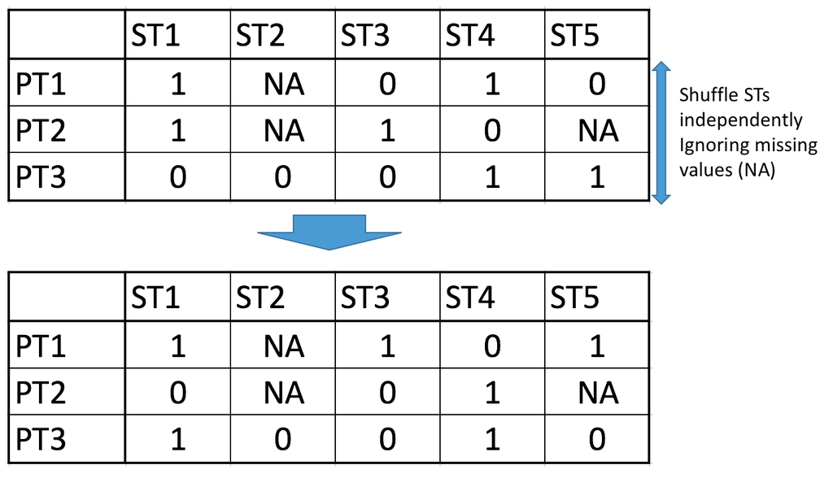

P-value is obtained from a one-tailed test.

### Data Structure

Example data structure expected. A cleaned version of phenotype and plasmid data used in this analysis can be found in the `data` folder.

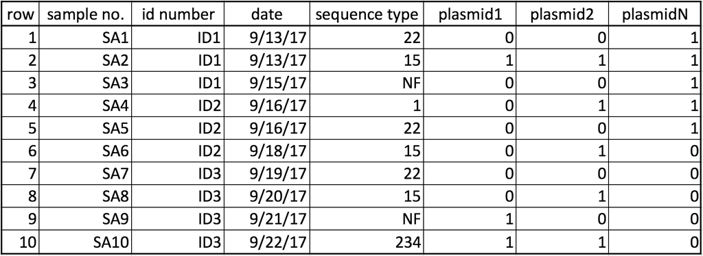

A data structure generated from one of the functions provided will look as such:

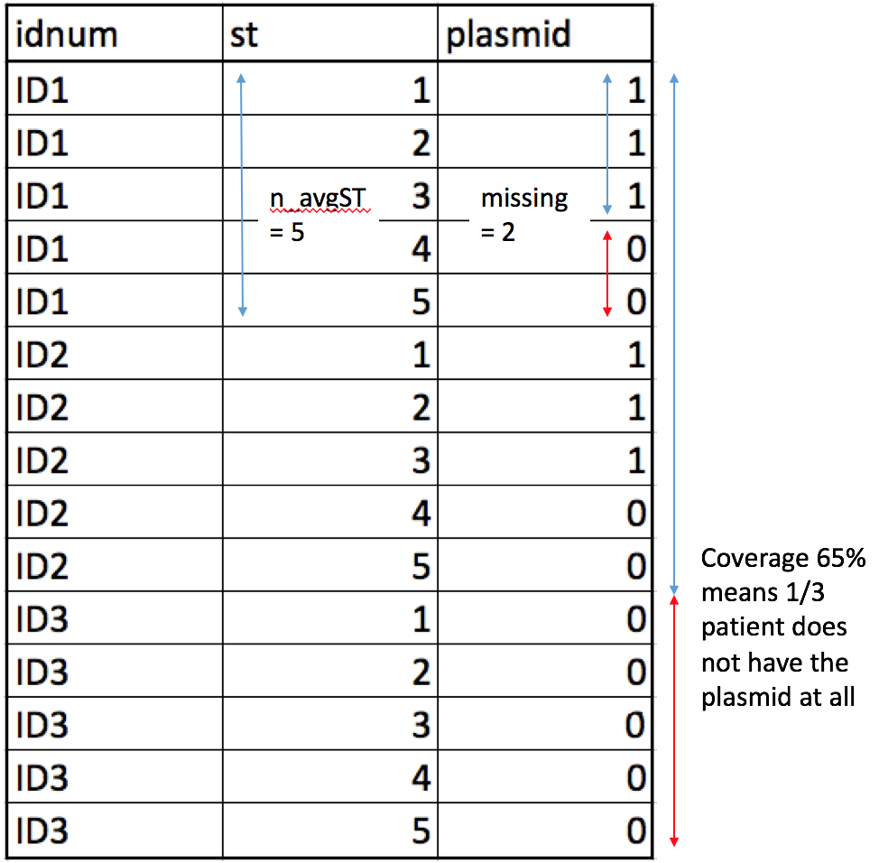

More details on each function can be found under Files & Functions or in source.

### Workflow

This section shows how each functions are meant to be used together in a workflow.

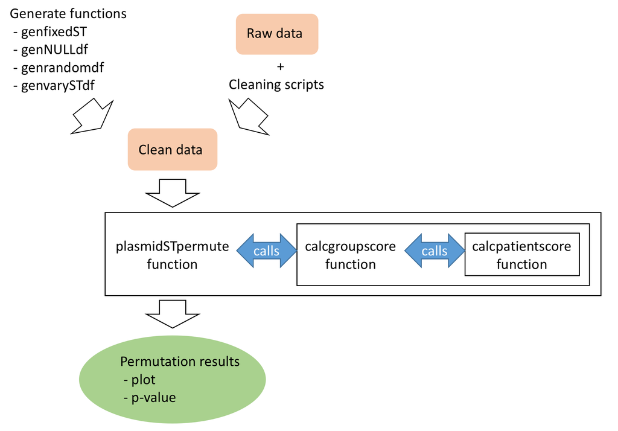

### Files & Functions

This section contains descriptions for each file and function. These descriptions can also be found with each function source comment.

#### Files

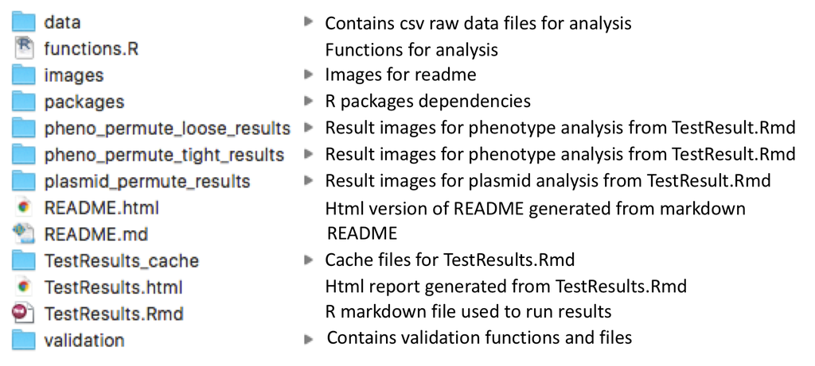

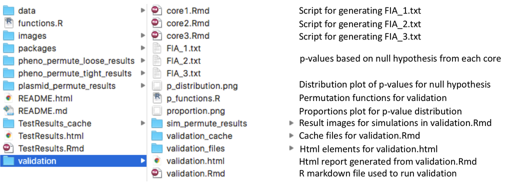

The only difference between `functions.R` and `p_functions.R` is the main function file returns a plot with p-value annotated on the plot, while the validation functions return a p-value numeric.

#### Functions

**genfixedSTdf**

Generates a simple test dataframe with each patient having fixed number of STs, and a fixed number of how many STs are missing the plasmid in a patient.

Args:  
n_patients (int): Number of patients in entire data set  
percent (int): Percentage of patients that will have the plasmid in a least 1 ST  
n_avgST (int): Number of ST per patient  
missing (int): Number of STs in a patient that will not have the plasmidNumber of STs in a patient that will not have the plasmid.

Ex. n_patients = 5 percent = 80 n_avgST = 5 with missing = 3 would mean a dataframe with 5 patients where 1 patient does not have the plasmid in any of their 5 STs. Remaining 4 patients would have 2 STs with the plasmid and 3 STs missing the plasmid.

Returns:  
Nothing. Creates a global variable with the name f_p<n_patients>_c<percent>_s<n_avgST>_m<missing>.

**genNULLdf**

Generates a test dataframe where whether each ST for each patient has the plasmid or not, is sampled from a binomial probability list given to the function.

Args:  
n_patients (int): Number of patients in entire data set  
percent (int): Percentage of patients that will have the plasmid in a least 1 ST  
n_avgST (int): Number of ST per patient  
ST_probs (float): Vector of probabilities [0-1] for each ST. Length must be same value as n_avgST.  
Where ex. c(0.2, 0.3, 0.5) correspond to probabilities for ST1, ST2, ST3.

Returns:  
Nothing. Creates a global variable with the name n_p_c_s.

**genvarySTdf**

Generates a test dataframe with each patient having a mean value of STs with a standard deviation, and a fixed number of how many STs are missing the plasmid in a patient.

Args:  
n_patients (int): Number of patients in entire data set  
percent (int): Percentage of patients that will have the plasmid in a least 1 ST  
n_ST_mean (float): Number of average STs per patient  
n_ST_sd (float): Standard deviation of STs per patient  
missing (int): Number of STs in a patient that will not have the plasmid

Returns:  
Nothing. Creates a global variable with the name v_p_c_s_v_n.

**genrandomdf**

Generates a test dataframe with a fixed number of patients and STs per patient where presence of plasmid is random.

Args:  
n_patients (int): Number of patients in entire data set  
n_avgST (int): Number of ST per patient

Returns:  
Nothing. Creates a global variable with the name r_p_c_s.

**plasmidSTpermute**

Performs permutation test on dataframe given. Calls other non-data-generating functions by itself.

Args:  
plasmid_df (data.frame): A data frame with the following columns; idnum (patient), st (number), presence (binary). Or if columns exceed 3, it will drop 1st and 3rd column to try to get the 3 mentioned. See readme on data structures.  
iterations (int): Number of times permutation is done to generate random distribution.

Returns:  
p (plot): plot result of permutation test

**calcpatientscore**

Calculates patient score. Will be called by calcgroupscore function.

Args:  
plasmid (data.frame): A data frame with the following columns; idnum (patient), st (number), presence (binary). See readme on data structures.

Returns:  
patientscore (float): Vector of scores for each patient.

**calcgroupscore**

Calculates group score. Will be called by plasmidSTpermute function.

Args:  
plasmid_df (data.frame): A data frame with the following columns; idnum (patient), st (number), presence (binary). See readme on data structures.

Returns:  
groupscore (float): Groupscore for dataframe.

### Validation

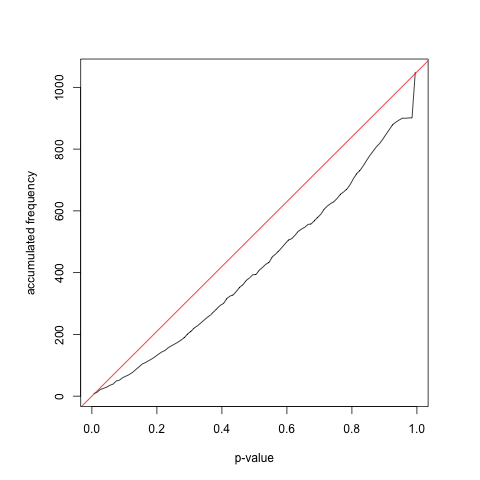

The `validation` folder contains the entire body of work and method. See validation.Rmd and it’s corresponding html file for a more detailed report.

### Example Scripts

More examples can found in TestResults.Rmd.

> iterations <- 1e3  
> plasmid <- select(whole_dataframe, c(1:5)) #only columns as described in data structure section  
> result <- plasmidSTpermute(plasmid, iterations)